# Statcast Metrics: Analyzing and Predicting San Diego Padres Performance

#### Scatterplot: Barrels vs. Total Home Runs

The scatterplot shows a positive linear relationship between barrels and total home runs suggesting that an increase in barrels correlates with a higher number of home runs.

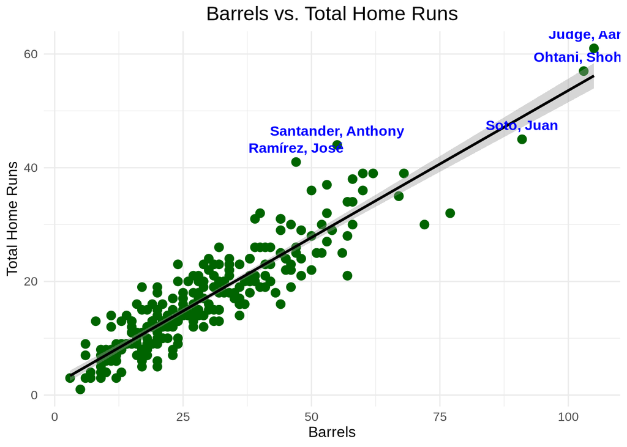

```r
outliers <- all_player_stats |>
  arrange(desc(hr_total)) |>
  slice(1:5) # Top 5 players with the most home runs
ggplot(all_player_stats, aes(x = barrels, y = hr_total)) +
  geom_point(color = "darkgreen", size = 3) +
  geom_smooth(method = "lm", color = "black", se = TRUE) +
  geom_text(
    data = outliers,
    aes(label = player),
    vjust = -1, hjust = 0.5, color = "blue", size = 4, fontface = "bold"
  ) +
  labs(
    title = "Barrels vs. Total Home Runs",
    x = "Barrels",
    y = "Total Home Runs"
  ) +
  theme_minimal() +
  theme(
    plot.title = element_text(hjust = 0.5, size = 16),
    axis.title = element_text(size = 12),
    axis.text = element_text(size = 10)
  )
```

## Results & Discussion

Some key takeaways from the analysis are that 1) barrels are the most important driving factor in determining performance, significantly outperforming the next best factors (average hit speed and expected home runs) in predictive power using the random forest model. 2) The R^2 value for the linear regression model is 0.93, which means that the model can explain 93% of the variance in home run totals with low error. 3) The model accurately predicts actual home runs. From the two scatterplots directly above, we can see that data points fit tightly around the predicted values. This analysis highlights the Statcast metrics that best produce home runs, includes multiple models to evaluate player performance, achieves a highly predictive model with linear regression, and applies the models across the Padres as well as the entire MLB, ensuring that the relationship between barrels and home runs is consistent. Additionally, barrels emerged as the most significant predictor of home run performance, showing higher predictive power than other key metrics like average hit speed and expected home runs, as assessed by the random forest model. As mentioned in the analysis above, some of the metrics we used could be correlated, which may distort their effects on home runs (multicollinearity). Another limitation in this analysis is that the only metrics considered were those collected by the MLB and not external factors like weather, field irregularities, etc. These factors can potentially influence home run performance significantly. Altogether, we can generally expect the home run performance of San Diego Padres players to be good if we have high barrels and high average hit speed. Teams can use predictive models during player scouting to identify potential high performers based on barrels and exit velocity. Additionally, focusing on improving players’ launch angles could further optimize performance.